# scATAC-seq Rat Metrial Glands

Ha T. H. Vu

This is a documentation for analyses of scATAC-seq data, generated from rat metrial gland tissues on gestational day (GD) 15.5 and 19.5.

```r
library("org.Rn.eg.db")
library("clusterProfiler")

go <- function(genes) {
  GO <- enrichGO(gene = genes, OrgDb=org.Rn.eg.db, ont = "BP", pvalueCutoff = 0.05, qvalueCutoff = 0.05, maxGSSize=500, readable = T, keyType = "ENSEMBL")
  goSimplify <- simplify(GO)
  res <- as.data.frame(goSimplify)
  #res$Rank <- seq(1, nrow(res))
  res$GeneRatio <- sapply(strsplit(res$GeneRatio, "/"), function(x) as.numeric(x[1])/as.numeric(x[2]))
  res$BgRatio <- sapply(strsplit(res$BgRatio, "/"), function(x) as.numeric(x[1])/as.numeric(x[2]))
  res$Fold <- as.numeric(res$GeneRatio)/as.numeric(res$BgRatio)
  res <- res[res$qvalue <= 0.05 & res$Fold >= 2 & res$Count >= 5,]

  return(res)
}
```

## GD 15.5:

```r
library(Signac)
library(Seurat)
library(ggplot2)
library(ggpubr)
library(GenomicRanges)
library(patchwork)
library(BSgenome.Rnorvegicus.Ensembl.rn6)
set.seed(1234)

load("/work/LAS/geetu-lab/hhvu/project3_scATAC/rnor6.rda")
load("/work/LAS/geetu-lab/hhvu/project3_scATAC/rnor6.ranges.rda")
load("/work/LAS/geetu-lab/hhvu/project3_scATAC/scATAC-seq-analysis/4_RNAintegration/scRNA-seqFiles/gd15.5_res0.8.rda")

exp <- AverageExpression(data)
exp <- as.data.frame(exp$RNA)

load("/work/LAS/geetu-lab/hhvu/project3_scATAC/scATAC-seq-analysis/4_RNAintegration/2_MACS2Peaks/annotation_scRNAseq/gd15.5-ATACwithRNAlables.rda")
Idents(rats) <- rats@meta.data$predicted.id # change from old identities to those predicted by scRNA-seq
DefaultAssay(rats) <- 'MACSpeaks'
Annotation(rats) <- rnor6.ranges
```

Invasive trophoblast cells:  
Genes with >= 3 peaks tend to be higher expressed:

```r
closest_genes <- read.table("/work/LAS/geetu-lab/hhvu/project3_scATAC/scATAC-seq-analysis/4_RNAintegration/2_MACS2Peaks/annotation_scRNAseq/gd15.5-tbc-toGenes.txt", sep = "\t")
marker <- read.table("/work/LAS/geetu-lab/hhvu/project3_scATAC/scATAC-seq-analysis/4_RNAintegration/scRNA-seqFiles/gd15.5-wilcoxin-cluster23.txt", header = T)

t <- table(closest_genes$gene_name)

genes <- names(t[t >= 3])

exp <- exp[order(rownames(exp)),]
exp$gene <- rownames(exp)
df <- exp[exp$gene %in% names(t), c("gene", "23")]
colnames(df) <- c("gene", "value")
df2 <- data.frame(gene = setdiff(names(t), df$gene), value = rep(0, length(setdiff(names(t), df$gene))))
names(df2) <- colnames(df)
df <- rbind(df, df2)

df$category <- ifelse(df$gene %in% genes, ">= 3 peaks", "< 3 peaks")

wilcox.test(df[df$category == ">= 3 peaks", "value"], df[df$category == "< 3 peaks", "value"])
```

```
#>
#>  Wilcoxon rank sum test with continuity correction
#>
#> data:  df[df$category == ">= 3 peaks", "value"] and df[df$category == "< 3 peaks", "value"]
#> W = 384806, p-value = 7.029e-09
#> alternative hypothesis: true location shift is not equal to 0
```

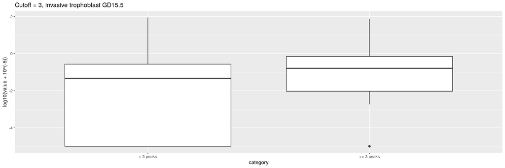

```r
ggplot(df, aes(x=category, y=log10(value+10^(-5)))) + geom_boxplot() + ggtitle("Cutoff = 3, invasive trophoblast GD15.5")
```

```r
print("Number of genes with >= 3 peaks:")
```

```
#> [1] "Number of genes with >= 3 peaks:"
```

```r
length(genes)
```

```
#> [1] 274
```

```r
print("Number of genes with < 3 peaks:")
```

```
#> [1] "Number of genes with < 3 peaks:"
```

```r
length(unique(df[df$category == "< 3 peaks", "gene"]))
```

```
#> [1] 2320
```

TBC non-specific peaks:

```r
c <- rownames(rats@meta.data[rats@meta.data$predicted.id == "Invasive trophoblast cells",])
atac2 <- rats@assays$MACSpeaks[,c]
atac3 <- atac2[rowMeans(atac2) > 0,]
atac3 <- atac2[rowSums(atac2 > 0) >= ncol(atac2)/10, ]

rats1.marker <- read.table("/work/LAS/geetu-lab/hhvu/project3_scATAC/scATAC-seq-analysis/4_RNAintegration/2_MACS2Peaks/annotation_scRNAseq/gd15.5-unfilteredMarkers.txt", header = T, sep = "\t", quote = "", stringsAsFactors = T, fill = T)
spePeaks <- rats1.marker[rats1.marker$cluster == "Invasive trophoblast cells" & rats1.marker$avg_log2FC >= log2(1.5) & rats1.marker$p_val_adj <= 0.05,]
nonspePeaks <- setdiff(rownames(atac3), spePeaks$gene)
length(nonspePeaks)
```

```
#> [1] 18760
```

```r
closest_genes <- ClosestFeature(rats, regions = nonspePeaks)

t <- table(closest_genes$gene_name)

genes <- names(t[t >= 3])

exp <- exp[order(rownames(exp)),]
exp$gene <- rownames(exp)
df <- exp[exp$gene %in% names(t), c("gene", "23")]
colnames(df) <- c("gene", "value")
df2 <- data.frame(gene = setdiff(names(t), df$gene), value = rep(0, length(setdiff(names(t), df$gene))))
names(df2) <- colnames(df)
df <- rbind(df, df2)

df$category <- ifelse(df$gene %in% genes, ">= 3 peaks", "< 3 peaks")

wilcox.test(df[df$category == ">= 3 peaks", "value"], df[df$category == "< 3 peaks", "value"])
```

```
#>
#>  Wilcoxon rank sum test with continuity correction
#>
#> data:  df[df$category == ">= 3 peaks", "value"] and df[df$category == "< 3 peaks", "value"]
#> W = 9359126, p-value < 2.2e-16
#> alternative hypothesis: true location shift is not equal to 0
```

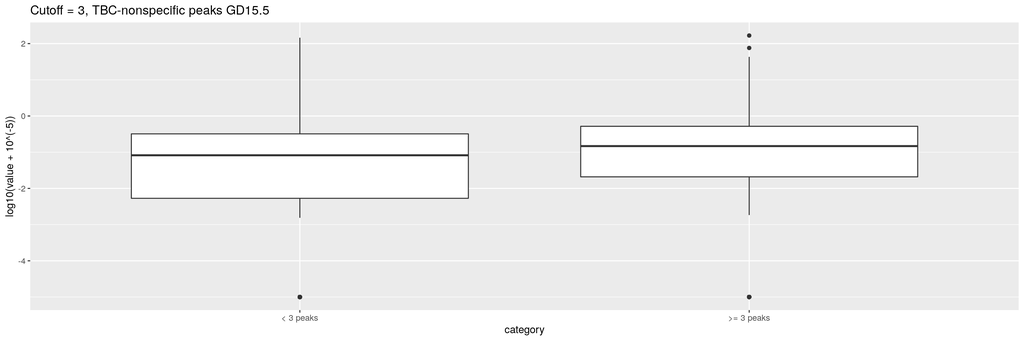

```r
ggplot(df, aes(x=category, y=log10(value+10^(-5)))) + geom_boxplot() + ggtitle("Cutoff = 3, TBC-nonspecific peaks GD15.5")
```

```r
print("Number of genes with >= 3 peaks:")
```

```
#> [1] "Number of genes with >= 3 peaks:"
```

```r
length(genes)
```

```
#> [1] 1710
```

```r
print("Number of genes with < 3 peaks:")
```

```
#> [1] "Number of genes with < 3 peaks:"
```

```r
length(unique(df[df$category == "< 3 peaks", "gene"]))
```

```
#> [1] 9575
```

```r
goGenes3Peaks <- go(rnor6[rnor6$gene_name %in% genes, 1])
goGenes3Peaks[grep("epithe|migration|branching|placenta|embryo", goGenes3Peaks$Description),]
```

```
#>                    ID                                   Description  GeneRatio
#> GO:0001890 GO:0001890                          placenta development 0.03057065
#> GO:0010631 GO:0010631                     epithelial cell migration 0.04008152
#> GO:0001701 GO:0001701                in utero embryonic development 0.05706522
#> GO:0090132 GO:0090132                          epithelium migration 0.04008152
#> GO:0060562 GO:0060562                 epithelial tube morphogenesis 0.04687500
#> GO:0010632 GO:0010632       regulation of epithelial cell migration 0.03260870
#> GO:0030856 GO:0030856 regulation of epithelial cell differentiation 0.02241848
#>                BgRatio       pvalue     p.adjust       qvalue
#> GO:0001890 0.010613002 5.341788e-11 2.725604e-08 1.998527e-08
#> GO:0010631 0.016354463 7.442442e-11 2.930337e-08 2.148646e-08
#> GO:0001701 0.027605405 9.530264e-11 3.480484e-08 2.552036e-08
#> GO:0090132 0.016470452 1.001832e-10 3.480484e-08 2.552036e-08
#> GO:0060562 0.021921939 1.066492e-09 2.099567e-07 1.539490e-07
#> GO:0010632 0.012990779 1.900460e-09 3.507537e-07 2.571873e-07
#> GO:0030856 0.008757177 3.876584e-07 2.360320e-05 1.730685e-05
#>                                                                                                                                                                                                                                                                                                          …
#> GO:0001890                                                                                                                                                                                                                                                   Fosl1/Nr2f2/Adm/E2f8/Cited2/Cdkn1c/Esr1/Grb2…
#> GO:0010631                                                                                                                                                        Anxa1/Dock1/Pik3c2a/Nr2f2/Prkd2/Sash1/Sparc/Jup/Prkca/Ppm1f/…
#> GO:0001701 RGD1560020_predicted/Fosl1/Nr2f2/Adm/P2ry2/E2f8/Cited2/Coq7/Tjp1/Cdkn1c…
#> GO:0090132                                                                                                                                                        Anxa1/Dock1/Pik3c2a/Nr2f2/Prkd2/Sash1/Sparc/Jup/Prkca/Ppm1f/…
#> GO:0060562                                                                                               Mthfd1l/Wnt11/Tead1/Adm/Mical2/Vasp/Rgma/Cited2/Pak1/Coq7/Su…
#> GO:0010632                                                                                                                                                                                                                   Anxa1/Dock1/Pik3c2a/Nr2f2/Prkd2/Sash1/Sparc/Jup/Prkca/Ppm1f/…
#> GO:0030856                                                                                                                                                                                                                                                                                               …
#>            Count     Fold
#> GO:0001890    45 2.880490
#> GO:0010631    59 2.450800
#> GO:0001701    84 2.067176
#> GO:0090132    59 2.433541
#> GO:0060562    69 2.138269
#> GO:0010632    48 2.510142
#> GO:0030856    33 2.560012
#>  [ reached 'max' / getOption("max.print") -- omitted 12 rows ]
```

```r
intersect(genes, marker$gene) #cited2 has 3 non-specific peaks
```

```
#>  [1] "AABR07027306.1" "Actn1"          "Ada"            "Adamts9"
#>  [5] "Anxa2"          "Apc"            "Arf6"           "Arhgap21"
#>  [9] "Arhgap8"        "Atxn10"         "B4galt5"        "Basp1"
#> [13] "Bend5"          "Btg2"           "C1qtnf6"        "Cald1"
#> [17] "Cd47"           "Cdc42bpb"       "Cdh5"           "Cdkn1c"
#> [21] "Cfdp1"          "Cited2"         "Cln8"           "Col4a1"
#> [25] "Coro1c"         "Cotl1"          "Crem"           "Crispld2"
#> [29] "Daam1"          "Dab2ip"         "Dhrs9"          "Dst"
#> [33] "Dynll2"         "Dyrk2"          "Eif4b"          "Eif4e3"
#> [37] "Ets2"           "Ezr"            "Fam110b"        "Fam78b"
#> [41] "Fblim1"         "Fbln1"          "Fbxw8"          "Fermt2"
#> [45] "Fgr"            "Flnb"           "Gata3"          "Gbe1"
#> [49] "Gna14"          "Gng12"          "Grb2"           "H2afy"
#> [53] "Hdac4"          "Ier3"           "Igf2bp2"        "Igsf3"
#> [57] "Irak2"          "Itga5"          "Itgb6"          "Jarid2"
#> [61] "Jdp2"           "Jup"            "Klc1"           "Klhl2"
#> [65] "Krt8"           "Lama5"          "Lamb1"          "Lamc1"
#> [69] "Lcp1"           "Lgmn"           "Lima1"          "LOC100362023"
#> [73] "LOC689959"      "Lrrfip1"        "Man2a1"
#>  [ reached getOption("max.print") -- omitted 62 entries ]
```

```r
print("Number of markers with >= 3 non-specific peaks:")
```

```
#> [1] "Number of markers with >= 3 non-specific peaks:"
```

```r
length(intersect(genes, marker$gene))
```

```
#> [1] 137
```

```r
goMarkers3Peaks <- go(rnor6[rnor6$gene_name %in% intersect(genes, marker$gene), 1])
goMarkers3Peaks[grep("epithe|migration|branching|placenta|embryo", goMarkers3Peaks$Description),]
```

```
#>                    ID                                   Description  GeneRatio
#> GO:0001890 GO:0001890                          placenta development 0.06976744
#> GO:0001701 GO:0001701                in utero embryonic development 0.10852713
#> GO:0030856 GO:0030856 regulation of epithelial cell differentiation 0.06201550
#> GO:0010632 GO:0010632       regulation of epithelial cell migration 0.06201550
#> GO:0001667 GO:0001667                 ameboidal-type cell migration 0.07751938
#> GO:0090132 GO:0090132                          epithelium migration 0.06201550
#>                BgRatio       pvalue    p.adjust      qvalue
#> GO:0001890 0.010613002 9.634818e-06 0.004139156 0.003544143
#> GO:0001701 0.027605405 1.324927e-05 0.004218957 0.003612472
#> GO:0030856 0.008757177 1.789994e-05 0.004675139 0.004003078
#> GO:0010632 0.012990779 2.836751e-04 0.021754723 0.018627434
#> GO:0001667 0.023777765 1.031261e-03 0.037028426 0.031705509
#> GO:0090132 0.016470452 1.341373e-03 0.041041415 0.035141623
#>                                                                                          geneID
#> GO:0001890                              Cited2/Cdkn1c/Grb2/Serpine1/Fbxw8/Pcdh12/Snai1/Ada/Krt8
#> GO:0001701 Cited2/Cdkn1c/Grb2/Fbxw8/Ncor2/Gata3/Pcdh12/Snai1/Ada/Tfap2c/Krt8/Mtss1/Man2a1/Usp9x
#> GO:0030856                                 Cdkn1c/Serpine1/Macroh2a1/Gata3/Apc/Cdh5/Wwtr1/S1pr2
#> GO:0010632                                   Jup/Serpine1/Coro1c/Gata3/Dab2ip/Adamts9/Arf6/Lgmn
#> GO:0001667                      Jup/Serpine1/Coro1c/Gata3/Lama5/Dab2ip/Sema6d/Adamts9/Arf6/Lgmn
#> GO:0090132                                   Jup/Serpine1/Coro1c/Gata3/Dab2ip/Adamts9/Arf6/Lgmn
#>            Count     Fold
#> GO:0001890     9 6.573770
#> GO:0001701    14 3.931373
#> GO:0030856     8 7.081678
#> GO:0010632     8 4.773810
#> GO:0001667    10 3.260163
#> GO:0090132     8 3.765258
```

So with peaks not TBC specific, the same trend is observed: genes with more peaks tend to higher expressed.

TBC markers with TBC-nonspecific peaks: 326 out of 394 markers have non-specific peaks.

```r
markersWithNonspePeaks <- intersect(df$gene, marker$gene)
length(markersWithNonspePeaks)
```

```
#> [1] 326
```

```r
markersWithNonspePeaks
```

```
#>  [1] "AABR07027306.1" "AABR07054614.1" "Abcg1"          "Actn1"
#>  [5] "Ada"            "Adamts9"        "Adarb1"         "Adgrg3"
#>  [9] "Adgrg6"         "Afmid"          "Agrn"           "Akr1c14"
#> [13] "Alad"           "Alkbh5"         "Ankrd17"        "Anxa2"
#> [17] "Apbb1ip"        "Apc"            "Arf6"           "Arhgap21"
#> [21] "Arhgap8"        "Arhgdib"        "Arl16"          "Arpc1b"
#> [25] "Ascl2"          "Ash2l"          "Atxn10"         "B4galnt4"
#> [29] "B4galt5"        "Barx2"          "Basp1"          "Bcl7c"
#> [33] "Bend5"          "Bex3"           "Btg2"           "C1qtnf6"
#> [37] "Cab39"          "Cald1"          "Ccdc88a"        "Cd164"
#> [41] "Cd200"          "Cd24"           "Cd47"           "Cd82"
#> [45] "Cdc34"          "Cdc42bpb"       "Cdh5"           "Cdkn1c"
#> [49] "Ceacam9"        "Cfap20"         "Cfdp1"          "Cfl2"
#> [53] "Chsy1"          "Cited1"         "Cited2"         "Ckap4"
#> [57] "Ckb"            "Cln8"           "Clstn3"         "Cmas"
#> [61] "Col4a1"         "Coro1c"         "Cotl1"          "Crem"
#> [65] "Crispld2"       "Csnk1e"         "Csnk1g2"        "Ctnnbip1"
#> [69] "Cxxc1"          "Daam1"          "Dab2ip"         "Dbn1"
#> [73] "Ddx3x"          "Dhrs9"          "Dmkn"
#>  [ reached getOption("max.print") -- omitted 251 entries ]
```

```r
markersWithNonspePeaks15.5 <- markersWithNonspePeaks
```

Expression of TBC markers with and without non-specific peaks:

```r
dat <- exp[exp$gene %in% df$gene, c("gene", "23")]
dat$cat <- ifelse(dat$gene %in% markersWithNonspePeaks, "markersWithNonspePeaks", "markersWithoutNonspePeaks")

wilcox.test(dat[dat$cat == "markersWithNonspePeaks", "23"], dat[dat$cat == "markersWithoutNonspePeaks", "23"])
```

```
#>
#>  Wilcoxon rank sum test with continuity correction
#>
#> data:  dat[dat$cat == "markersWithNonspePeaks", "23"] and dat[dat$cat == "markersWithoutNonspePeaks", "23"]
#> W = 3214864, p-value < 2.2e-16
#> alternative hypothesis: true location shift is not equal to 0
```

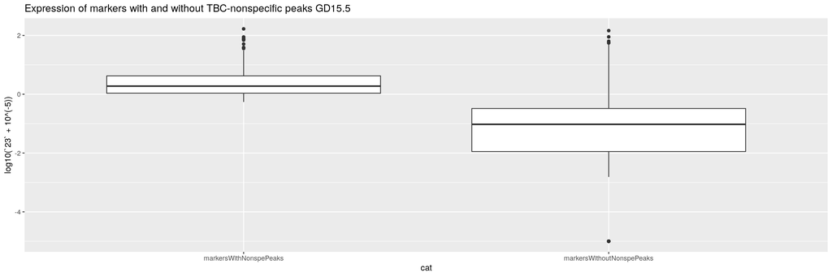

```r
ggplot(dat, aes(x=cat, y=log10(`23`+10^(-5)))) + geom_boxplot() + ggtitle("Expression of markers with and without TBC-nonspecific peaks GD15.5")
```

Gene ontology of markers with and without non-specific peaks:

```r
with <- go(rnor6[rnor6$gene_name %in% markersWithNonspePeaks, 1])
without <- go(rnor6[rnor6$gene_name %in% dat[dat$cat == "markersWithoutNonspePeaks", 1], 1])

with[grep("epithe|migration|branching|placenta|embryo", with$Description),]
```

```
#>                    ID                                   Description  GeneRatio
#> GO:0001667 GO:0001667                 ameboidal-type cell migration 0.08000000
#> GO:0001890 GO:0001890                          placenta development 0.05000000
#> GO:0010632 GO:0010632       regulation of epithelial cell migration 0.05333333
#> GO:0090132 GO:0090132                          epithelium migration 0.05333333
#> GO:0030856 GO:0030856 regulation of epithelial cell differentiation 0.03666667
#> GO:0001701 GO:0001701                in utero embryonic development 0.06666667
#> GO:0001755 GO:0001755                   neural crest cell migration 0.02000000
#>                BgRatio       pvalue     p.adjust       qvalue
#> GO:0001667 0.023777765 2.355031e-07 0.0002396833 0.0001991861
#> GO:0001890 0.010613002 7.602040e-07 0.0005157984 0.0004286484
#> GO:0010632 0.012990779 2.032360e-06 0.0008342973 0.0006933332
#> GO:0090132 0.016470452 4.002070e-05 0.0052677660 0.0043777165
#> GO:0030856 0.008757177 6.831747e-05 0.0066219143 0.0055030660
#> GO:0001701 0.027605405 2.673594e-04 0.0157074867 0.0130535268
#> GO:0001755 0.003421678 5.480134e-04 0.0237336457 0.0197235743
#>                                                                                                                                                     geneID
#> GO:0001667 Igf2/Pfn1/Jup/Serpine1/Coro1c/Fgfbp1/Gata3/Hmox1/Plk2/Efna1/Lama5/Dab2ip/Sema6d/Src/Pparg/Arhgdib/Adamts9/Arf6/Lgmn/Mmp12/Mmp1/Fn1/Sema4c/Efnb1
#> GO:0001890                                                  Igf2/Ascl2/Cited2/Cdkn1c/Grb2/Serpine1/Fbxw8/Pcdh12/Hsd17b2/Snai1/Ada/Pparg/Dnajb6/Krt8/Cited1
#> GO:0010632                                                  Igf2/Pfn1/Jup/Serpine1/Coro1c/Fgfbp1/Gata3/Hmox1/Plk2/Efna1/Dab2ip/Src/Pparg/Adamts9/Arf6/Lgmn
#> GO:0090132                                                  Igf2/Pfn1/Jup/Serpine1/Coro1c/Fgfbp1/Gata3/Hmox1/Plk2/Efna1/Dab2ip/Src/Pparg/Adamts9/Arf6/Lgmn
#> GO:0030856                                                                          Cdkn1c/Serpine1/Macroh2a1/Gata3/Apc/Cdh5/Wwtr1/Cd24/Srsf6/S1pr2/Cited1
#> GO:0001701                    Igf2/Ascl2/Cited2/Cdkn1c/Grb2/Hs3st6/Fbxw8/Ncor2/Gata3/Pcdh12/Hsd17b2/Snai1/Ada/Tfap2c/Dnajb6/Krt8/Mtss1/Man2a1/Cited1/Usp9x
#> GO:0001755                                                                                                            Coro1c/Lama5/Sema6d/Fn1/Sema4c/Efnb1
#>            Count     Fold
#> GO:0001667    24 3.364488
#> GO:0001890    15 4.711202
#> GO:0010632    16 4.105476
#> GO:0090132    16 3.238122
#> GO:0030856    11 4.187042
#> GO:0001701    20 2.414986
#> GO:0001755     6 5.845085
#>  [ reached 'max' / getOption("max.print") -- omitted 2 rows ]
```

```r
without[grep("epithe|migration|branching|placenta|embryo", without$Description),]
```

```
#>  [1] ID          Description GeneRatio   BgRatio     pvalue      p.adjust
#>  [7] qvalue      geneID      Count       Fold
#> <0 rows> (or 0-length row.names)
```